# Chapter 1: Sampling and Data

Section 1.1: Definitions of Statistics, Probability, and Key Terms

Author

Aaron R. Baggett, Ph.D.

Published

August 19, 2025

## Why? ⁉️

Well, it’s because statistics, at its very heart, is the science of understanding phenomena. It’s a tool that allows us to challenge anecdotes in exchange for empirical evidence. Statistics help us explore broader truths about human behavior and society all by using data. Of course, it’s about collecting, analyzing, interpreting, and presenting evidence. But the real key here is that it’s an entire process. Statistics isn’t just about crunching numbers in a calculator? That calculation part is just one piece of the puzzle. The real goal is to understand what our data might be trying to tell us and then communicate the results clearly and technically.

## The Two Branches 🙌

So, statistics basically has two main branches:

1. Descriptive statistics
2. Inferential statistics

Think of it like this. **Descriptive statistics** is all about describing what you can literally see. You collect data on the sleep habits of UMHB students and find that 56% of those in your sample get less than 8-hours of sleep per night. OK, so what?!

But **inferential statistics** is all about making an educated guess about what you can’t see. We’re not necessarily interested in data from our sample only. We’re interested in the sleep habits of the entire population–in this case, UMHB students. So, in this case, we could calculate a margin of error around the percentage of students who get less than 8-hours of sleep per night to give us a range within which the true population parameter ought to fall.

## Coming to Terms 🤟

But before we can start making those statistical inferences, we all need to be speaking the same language.

Let’s cover the key terms you’re going to see over and over and over again in this course. First up, **population** VS. **sample**.

### 🤔 What’s the difference?

So, the **population** is the entire group we want to learn about. Imagine you wanted to know exactly how every American voted during the 2024 presidential election. Trump, Biden, Other.

As of January 2025, over 340 million people live in the United States. Of those, 44.71% voted. That’s around 152,320,193 people (plus or minus a few 😜). Now, imagine having to get in touch with each voter to find out how they cast their ballot. Impossible.

### 🤔 We all agree it’s impossible. But, why is it?

Let’s say we want to know who every single college student in the United States voted for in the 2024 presidential election. Now, trying to study all of them, that’s basically impossible. So, what do we do? We take a **sample**, a smaller, much more manageable group that if we do it right, looks a lot like the larger population.

### 🤔 But, what does it mean for our sample to “look like” the larger population?

For every statistical **variable** in a population, there exists a **parameter.** For example, let’s say we’re interested in understanding the differences in the distributions of heights among all men and women in the United States. Well, without collecting a single data point, we do know that there is a value that exists which represents the actual and true height of all men and women.

That’s the **parameter**. It’s the elusive bulls eye of the dart board. 🎯

A **parameter** is a number that describes the entire population, like the true mean household income of all elementary teachers in the state of Texas. The thing is we almost never actually know this number.

What we can know is the **statistic**. This is the number we calculate from our sample.

Let’s say, we took a random sample of *n* = 300 men and *n* = 300 women from the population and measured their height. We find that the mean height of the men was around 5’9”. For women, the mean height was around 5’5”.

### 🤔 How do we know if these statistics represent the actual population?

And there’s the magic of inferential statistics. We use that statistic from our sample as our best educated guess to estimate that unknown parameter. That’s the whole game right there.

## Data 🧮

Now, the actual information we collect are called **data**. Data come in two main flavors:

1. Categorical
2. Numerical

First, you’ve got **categorical data**. Categorical data are things that can be sorted into groups or categories. Think hair color, college major, that kind of thing. Then you’ve got **numerical** or **quantitative data**. And that’s all about the numbers. It’s things you can count like the number of siblings you have or things you can measure like your height.

## Hold that Plane! ✈️

Let’s look at a set of data with information on commercial airline flights departing New York City during 2013. Go ahead and load the data below by clicking the green arrow in the code chunk. This button will send the request over to the R Console.

```r
# Load NYC flight data
data(nycflights)
```

```r
# View the data
print(nycflights)
```

```
# A tibble: 32,735 × 16
    year month   day dep_time dep_delay arr_time arr_delay carrier tailnum
   <int> <int> <int>    <int>     <dbl>    <int>     <dbl> <chr>   <chr>
 1  2013     6    30      940        15     1216        -4 VX      N626VA
 2  2013     5     7     1657        -3     2104        10 DL      N3760C
 3  2013    12     8      859        -1     1238        11 DL      N712TW
 4  2013     5    14     1841        -4     2122       -34 DL      N914DL
 5  2013     7    21     1102        -3     1230        -8 9E      N823AY
 6  2013     1     1     1817        -3     2008         3 AA      N3AXAA
 7  2013    12     9     1259        14     1617        22 WN      N218WN
 8  2013     8    13     1920        85     2032        71 B6      N284JB
 9  2013     9    26      725       -10     1027        -8 AA      N3FSAA
10  2013     4    30     1323        62     1549        60 EV      N12163
# ℹ 32,725 more rows
# ℹ 7 more variables: flight <int>, origin <chr>, dest <chr>, air_time <dbl>,
#   distance <dbl>, hour <dbl>, minute <dbl>
```

```r
glimpse(nycflights)
```

```
Rows: 32,735
Columns: 16
$ year      <int> 2013, 2013, 2013, 2013, 2013, 2013, 2013, 2013, 2013, 2013, …
$ month     <int> 6, 5, 12, 5, 7, 1, 12, 8, 9, 4, 6, 11, 4, 3, 10, 1, 2, 8, 10…
$ day       <int> 30, 7, 8, 14, 21, 1, 9, 13, 26, 30, 17, 22, 26, 25, 21, 23, …
$ dep_time  <int> 940, 1657, 859, 1841, 1102, 1817, 1259, 1920, 725, 1323, 940…
$ dep_delay <dbl> 15, -3, -1, -4, -3, -3, 14, 85, -10, 62, 5, 5, -2, 115, -4, …
$ arr_time  <int> 1216, 2104, 1238, 2122, 1230, 2008, 1617, 2032, 1027, 1549, …
$ arr_delay <dbl> -4, 10, 11, -34, -8, 3, 22, 71, -8, 60, -4, -2, 22, 91, -6, …
$ carrier   <chr> "VX", "DL", "DL", "DL", "9E", "AA", "WN", "B6", "AA", "EV", …
$ tailnum   <chr> "N626VA", "N3760C", "N712TW", "N914DL", "N823AY", "N3AXAA", …
$ flight    <int> 407, 329, 422, 2391, 3652, 353, 1428, 1407, 2279, 4162, 20, …
$ origin    <chr> "JFK", "JFK", "JFK", "JFK", "LGA", "LGA", "EWR", "JFK", "LGA…
$ dest      <chr> "LAX", "SJU", "LAX", "TPA", "ORF", "ORD", "HOU", "IAD", "MIA…
$ air_time  <dbl> 313, 216, 376, 135, 50, 138, 240, 48, 148, 110, 50, 161, 87,…
$ distance  <dbl> 2475, 1598, 2475, 1005, 296, 733, 1411, 228, 1096, 820, 264,…
$ hour      <dbl> 9, 16, 8, 18, 11, 18, 12, 19, 7, 13, 9, 13, 8, 20, 12, 20, 6…
$ minute    <dbl> 40, 57, 59, 41, 2, 17, 59, 20, 25, 23, 40, 20, 9, 54, 17, 24…
```

### Let’s dive in! 🤿

What’s the difference between `print(nycflights)` and `glimpse(nycflights)`?

**1. What’s the difference between `print(nycflights)` and `glimpse(nycflights)`?**

The `print()` function displays each variable and the first 10 rows of the data inside the Console pane. The number of variables, or columns, we can see from the data in the Console is limited by the amount of horizontal space available in the window. This is the default behavior and can be a limitation when we want to see all the variables.

The `glimpse()` function, however, assumes our primary need is to see each of the variable names and a glimpse of the values or categories. When sent to the console, `glimpse()` arranges the variable names vertically and aligned on the left.

**2. How many flights are included in the data?**

Each row represents data points for, in this case, a single flight. This is pretty much the standard format in most all data we’ll work with. When we run the `glimpse(nycflights)` function the first results are the number of Rows (32,735) and the number of Columns (16).

You can always use the `nrow()` or `length()` commands to return the number of rows and columns. For example, `nrow(nycflights)` would return 32735.

**3. How many variables are represented in the data?**

Let’s use the `length(nycflights)` command to give us the exact number of variables present in the data. In this case, `length(nycflights)` returns 16

**4. What do you think the `dest` variable represents?**

`dest` is the variable name for the airport that particular flight was headed. As a standard practice, airports use three letter abbreviations. So, LAX would be the Los Angeles International Airport, BOS would be the Boston Logan International Airport, etc.

**5. What do you think the `dep_time` variable represents?**

`dep_time` is the departure time according to the 24-hour clock, or “military time” conventions.

**6. Find two categorical variables.**

1. `carrier`
2. `tailnum`

**7. Find three numerical variables.**

1. `dep_delay`
2. `distance`
3. `air_time`

**8. Now, calculate the mean of the `carrier` variable.**

```r
nycflights |>
  summarize(mean_dep_delay = mean(carrier))
```

🤔 Why doesn’t that work?

**8. Now, calculate the mean of the `carrier` variable.**

When working with categorical variables, we are limited to basically counting the number of times they appear. So, traditional statistical operations won’t work.

Here are all 16 of the airlines from our data and the number of times each one departed one of the three NYC airports in 2013.

```r
nycflights |>
  group_by(carrier) |>
  count(carrier) |>
  arrange(desc(n))
```

```
# A tibble: 16 × 2
# Groups:   carrier [16]
   carrier     n
   <chr>   <int>
 1 UA       5770
 2 B6       5376
 3 EV       5142
 4 DL       4751
 5 AA       3188
 6 MQ       2507
 7 US       2015
 8 9E       1696
 9 WN       1261
10 VX        497
11 FL        307
12 F9         69
13 AS         66
14 YV         53
15 HA         34
16 OO          3
```

**9. Calculate the mean of the `dep_delay` variable.**

```r
nycflights |>
  summarize(mean_dep_delay = mean(dep_delay))
```

```
# A tibble: 1 × 1
  mean_dep_delay
           <dbl>
1           12.7
```

**9. Calculate the mean of the `dep_delay` variable.**

Ignoring other factors, flights departing one of the three major New York City airports in 2013 were delayed by approximately 13 minutes.

## As a Team 🫛

**10. Think of at least two variables within the data that could potentially delay a flight’s departure time.**

1. `month`
2. `dest`

## Departure Delays by Month 🗓

To calculate the mean departure time by month we can use the `group_by()` function. This will group the flights together by their respective months and calculate separate means.

```r
nycflights |>
  group_by(month) |>
  summarize(mean_dep_delay = mean(dep_delay))
```

```
# A tibble: 12 × 2
   month mean_dep_delay
   <int>          <dbl>
 1     1          10.2
 2     2          10.7
 3     3          13.5
 4     4          14.6
 5     5          13.3
 6     6          20.4
 7     7          20.8
 8     8          12.6
 9     9           6.87
10    10           5.88
11    11           6.10
12    12          17.4
```

We can see noticeable variability in the departure delays when flights are grouped by month. Let’s sort the results by the `mean_dep_delay` variable we created in descending order.

```r
nycflights |>
  group_by(month) |>
  summarize(mean_dep_delay = mean(dep_delay)) |>
  arrange(desc(mean_dep_delay))
```

```
# A tibble: 12 × 2
   month mean_dep_delay
   <int>          <dbl>
 1     7          20.8
 2     6          20.4
 3    12          17.4
 4     4          14.6
 5     3          13.5
 6     5          13.3
 7     8          12.6
 8     2          10.7
 9     1          10.2
10     9           6.87
11    11           6.10
12    10           5.88
```

Here we can more clearly see that during the mid-summer and Christmas seasons, flights tend to be delayed by more time, on average.

## Departure Delays by Destination 🏙️

```r
nycflights |>
  group_by(dest) |>
  filter(dest %in% c("LAX", "BOS", "HOU")) |>
  summarize(mean_dep_delay = mean(dep_delay))
```

```
# A tibble: 3 × 2
  dest  mean_dep_delay
  <chr>          <dbl>
1 BOS             8.99
2 HOU            14.0
3 LAX             9.78
```

Departure delays for both Boston (*MD* = -3.71 mins.) and Los Angeles (*MD* = -2.92 mins.) are slightly lower than the average, while flights to Houston are delayed slightly above average (*MD* = 1.30 mins.)

Note: *MD* = mean difference.

Sometimes it’s better to visualize our data. Let’s build a line plot and visualize the trend in departure delays by month.

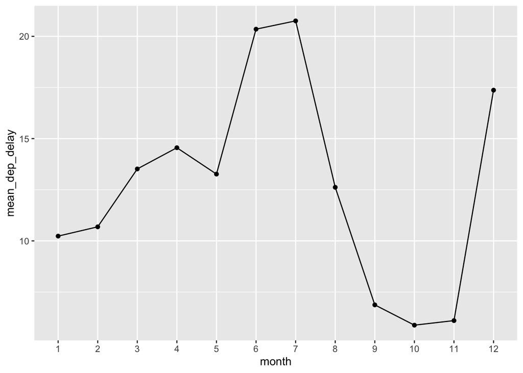

```r
month_delay <- nycflights |>
  mutate(month = as_factor(month)) |>
  group_by(month) |>
  summarize(mean_dep_delay = mean(dep_delay))

ggplot(data = month_delay,
       aes(x = month, y = mean_dep_delay, group = 1)) +
  geom_path() + geom_point()
```